# Базовые функции R на примере исследования данных о пропавших мигрантах

Морозова Ю.А., ymorozova@ya.ru

12 сентября 2017 г

## Описание набора данных

Данный пример подготовлен на основе набора данных [Missing Migrants Dataset](https://www.kaggle.com/jmataya/missingmigrants). Данные получены из Международной организации по миграции и являются частью проекта под названием Missing Migrants, цель которого - отслеживание случаев гибели мигрантов, в том числе беженцев, в процессе перемещения по миграционным маршрутам по всему миру. Исследования в рамках этого проекта начались после трагедии в октябре 2013 года, когда, по крайней мере, 368 человек погибли в результате двух кораблекрушений возле итальянского острова Лампедуза. С тех пор проект Missing Migrants превратился в важный источник, предоставляющий доступ СМИ, исследователям и широкой общественности к самой последней информации о пропавших мигрантах.

Данные имеют следующую структуру:  
1. id - идентификатор инцидента  
2. cause_of_death - причина смерти  
3. region_origin - регион происхождения мигрантов  
4. affected_nationality - национальность мигрантов  
5. missing - количество пропавших без вести  
6. dead - количество погибших  
7. incident_region - регион, в котором произошел инцидент  
8. date - дата, когда зафиксирован инцидент. В наборе данных собраны записи за период с 2014 года по июнь 2017.  
9. source - источник информации  
10. reliability - достоверность информации  
11. lat - географическая широта места, где произошел инцидент  
12. lon - географическая долгота, где произошел инцидент

```r
library(tidyverse)
mm <- read_csv("data/MissingMigrantsProject.csv")
```

## Очистка данных

В загруженном наборе данных 2420 строк и 12 столбцов. Первые 10 строк выглядят следующим образом:

```r
head(mm, 10)
```

```
## # A tibble: 10 x 12
##       id cause_of_death region_origin affected_nation~ missing  dead
##    <dbl> <chr>          <chr>         <chr>              <dbl> <dbl>
##  1     1 Presumed drow~ Middle East   Iraq                   1     1
##  2     3 Fell from tra~ Central Amer~ Honduras              NA     1
##  3     4 Presumed drow~ Middle East   <NA>                  NA     1
##  4     6 Drowning       MENA          <NA>                   6     4
##  5     7 Vehicle accid~ South East A~ Cambodia              NA     4
##  6     8 Drowning       MENA          <NA>                  NA    11
##  7     9 Drowning       MENA          <NA>                  NA     1
##  8    10 Drowning       MENA          <NA>                  NA     1
##  9    11 Drowning       <NA>          <NA>                   0     3
## 10    12 Died of unkno~ MENA          Syria                 NA     1
## # ... with 6 more variables: incident_region <chr>, date <chr>,
## #   source <chr>, reliability <chr>, lat <dbl>, lon <dbl>
```

С помощью функции `summary()` получим краткую статистическую сводку о распределении значений в исходном наборе данных:

```r
summary(mm)
```

```
##        id         cause_of_death     region_origin
##  Min.   :     1   Length:2420        Length:2420
##  1st Qu.: 28571   Class :character   Class :character
##  Median :121178   Mode  :character   Mode  :character
##  Mean   : 95926
##  3rd Qu.:144678
##  Max.   :184750
##
##  affected_nationality    missing            dead
##  Length:2420          Min.   :  0.00   Min.   :  0.000
##  Class :character     1st Qu.:  3.00   1st Qu.:  1.000
##  Mode  :character     Median : 10.00   Median :  1.000
##                       Mean   : 39.66   Mean   :  4.729
##                       3rd Qu.: 33.00   3rd Qu.:  3.000
##                       Max.   :750.00   Max.   :750.000
##                       NA's   :2149     NA's   :102
##  incident_region        date              source
##  Length:2420        Length:2420        Length:2420
##  Class :character   Class :character   Class :character
##  Mode  :character   Mode  :character   Mode  :character
##
##
##
##
##  reliability             lat              lon
##  Length:2420        Min.   :-26.22   Min.   :-117.07
##  Class :character   1st Qu.: 19.54   1st Qu.: -97.04
##  Mode  :character   Median : 29.35   Median :  14.47
##                     Mean   : 26.90   Mean   : -14.00
##                     3rd Qu.: 34.04   3rd Qu.:  32.01
##                     Max.   : 66.97   Max.   : 116.22
##                     NA's   :4        NA's   :4
```

Для числовых столбцов набора данных в сводке можно увидеть минимальные, максимальные значения, а также среднее, медиану, 1 и 3 квартиль, количество неизвестных значений (NA). Например, среднее количество пропавших без вести - 39.6568266 человек, при этом в 2149 случаях из 2420 количество пропавших неизвестно. Рассчитаем для каждого из столбцов количество неизвестных значений. Для этого нам нужно для каждого из столбцов проверить каждое значение, является ли оно неизвестным, с помощью функции `is.na()`. Функция `is.na()` для каждого значения вернет `true` или `false`. Далее с помощью функции `sum()` мы просуммируем значения `true`, выполнив эту операцию для каждого из столбцов набора данных `mm` с помощью функции `lapply()`:

```r
lapply(mm, FUN = function(x) {sum(is.na(x))})
```

```
## $id
## [1] 0
##
## $cause_of_death
## [1] 203
##
## $region_origin
## [1] 443
##
## $affected_nationality
## [1] 1575
##
## $missing
## [1] 2149
##
## $dead
## [1] 102
##
## $incident_region
## [1] 10
##
## $date
## [1] 9
##
## $source
## [1] 7
##
## $reliability
## [1] 324
##
## $lat
## [1] 4
##
## $lon
## [1] 4
```

Как видно из результатов, в некоторых столбцах количество отсутствующих значений велико. Наличие в наборе данных отсутствующих значений затрудняет анализ данных, поэтому для решения проблемы необходимо что-то предпринять. Самый простой способ - это удалить или отфильтровать строки с отсутствующими значениями. Например, можно отфильтровать отсутствующие значения в столбце `missing`, следующими способами:

```r
condition <- !is.na(mm$missing) ## вектор, в котором значение TRUE или FALSE соответсвует наличию или отсутствию значения в соответствующей строке столбца missing
str(condition)
```

```
##  logi [1:2420] TRUE FALSE FALSE TRUE FALSE FALSE ...
```

```r
mm[condition,] ## первый способ
```

```
## # A tibble: 271 x 12
##       id cause_of_death region_origin affected_nation~ missing  dead
##    <dbl> <chr>          <chr>         <chr>              <dbl> <dbl>
##  1     1 Presumed drow~ Middle East   Iraq                   1     1
##  2     6 Drowning       MENA          <NA>                   6     4
##  3    11 Drowning       <NA>          <NA>                   0     3
##  4    14 Presumed drow~ South Asia    Afghanistan            7     3
##  5    21 Drowning       <NA>          <NA>                  32     7
##  6    22 Drowning       Middle East/~ <NA>                   4     3
##  7    23 Drowning       Middle East/~ <NA>                   2    NA
##  8    30 Drowning       Middle East/~ <NA>                   1     3
##  9    36 Drowning       <NA>          <NA>                  13    43
## 10    37 Drowning       <NA>          <NA>                   1     1
## # ... with 261 more rows, and 6 more variables: incident_region <chr>,
## #   date <chr>, source <chr>, reliability <chr>, lat <dbl>, lon <dbl>
```

```r
subset(mm, condition) ## второй способ
```

```
## # A tibble: 271 x 12
##       id cause_of_death region_origin affected_nation~ missing  dead
##    <dbl> <chr>          <chr>         <chr>              <dbl> <dbl>
##  1     1 Presumed drow~ Middle East   Iraq                   1     1
##  2     6 Drowning       MENA          <NA>                   6     4
##  3    11 Drowning       <NA>          <NA>                   0     3
##  4    14 Presumed drow~ South Asia    Afghanistan            7     3
##  5    21 Drowning       <NA>          <NA>                  32     7
##  6    22 Drowning       Middle East/~ <NA>                   4     3
##  7    23 Drowning       Middle East/~ <NA>                   2    NA
##  8    30 Drowning       Middle East/~ <NA>                   1     3
##  9    36 Drowning       <NA>          <NA>                  13    43
## 10    37 Drowning       <NA>          <NA>                   1     1
## # ... with 261 more rows, and 6 more variables: incident_region <chr>,
## #   date <chr>, source <chr>, reliability <chr>, lat <dbl>, lon <dbl>
```

```r
filter(mm, condition) ## третий способ
```

```
## # A tibble: 271 x 12
##       id cause_of_death region_origin affected_nation~ missing  dead
##    <dbl> <chr>          <chr>         <chr>              <dbl> <dbl>
##  1     1 Presumed drow~ Middle East   Iraq                   1     1
##  2     6 Drowning       MENA          <NA>                   6     4
##  3    11 Drowning       <NA>          <NA>                   0     3
##  4    14 Presumed drow~ South Asia    Afghanistan            7     3
##  5    21 Drowning       <NA>          <NA>                  32     7
##  6    22 Drowning       Middle East/~ <NA>                   4     3
##  7    23 Drowning       Middle East/~ <NA>                   2    NA
##  8    30 Drowning       Middle East/~ <NA>                   1     3
##  9    36 Drowning       <NA>          <NA>                  13    43
## 10    37 Drowning       <NA>          <NA>                   1     1
## # ... with 261 more rows, and 6 more variables: incident_region <chr>,
## #   date <chr>, source <chr>, reliability <chr>, lat <dbl>, lon <dbl>
```

```r
filter(mm, complete.cases(mm)) ## фильтрация строк с пропущенными значениями в хотя бы одном из столбцов
```

```
## # A tibble: 89 x 12
##       id cause_of_death region_origin affected_nation~ missing  dead
##    <dbl> <chr>          <chr>         <chr>              <dbl> <dbl>
##  1     1 Presumed drow~ Middle East   Iraq                   1     1
##  2    14 Presumed drow~ South Asia    Afghanistan            7     3
##  3    50 Drowning       Sub-Saharan ~ Senegal                1     1
##  4    56 Drowning       MENA          Syrian                 1     4
##  5    59 Drowning       Middle East   Iraqi                  3     4
##  6    70 Drowning       Middle East   Lebanese               2     7
##  7    86 Drowning       MENA          Syria                  5     1
##  8    97 Drowning       Middle East   Syrian Kurds          24     2
##  9   132 Drowning       Caribbean     Haiti                 19    21
## 10   133 Drowning       MENA          Syria, Iraq            4     7
## # ... with 79 more rows, and 6 more variables: incident_region <chr>,
## #   date <chr>, source <chr>, reliability <chr>, lat <dbl>, lon <dbl>
```

Однако, в результате такой “чистки” может остаться очень малая доля исходных данных, и нам будет нечего анализировать. В нашем случае после фильтрации всех пустых значений в выборке осталось всего 89 строк. Иногда наиболее предпочтительно заменить неизвестные значения на значения по умолчанию, например, “Unknown” или наиболее типичное (среднее или медиану). Это можно сделать несколькими способами:

```r
mm[is.na(mm$cause_of_death),"cause_of_death"] <- "Unknown" ## первый способ: делаем выборку строк с отсутствующими значениями в столбце "cause_of_death" и для них задаем новое значение "Unknown"

mm[is.na(mm$affected_nationality),"affected_nationality"] <- "Unknown"

mm[is.na(mm$incident_region),"incident_region"] <- "Unknown"

median_missing <- median(mm$missing, na.rm = TRUE)
mm[is.na(mm$missing),"missing"] <- median_missing ## заменяем отсутствующие значения в столбце "missing" на медиану

mm[is.na(mm$dead),"dead"] <- 0 ## заменяем отсутствующие значения в столбце "dead" на 0

mm$region_origin <- ifelse(is.na(mm$region_origin),"Unknown", mm$region_origin) ## второй способ: для каждой строки проверяем условие и устанавливаем новое значение, если условие выполняется
```

Поскольку для столбца `date` сложно задать значение по умолчанию, а записей с отсутствующими датами всего 9, при этом количество погибших в этот неизвестный период зафиксировано всего 7 человек, отфильтруем эти записи из исходного набора данных.

```r
mm <- filter(mm, !is.na(mm$date))
lapply(mm, FUN = function(x) {sum(is.na(x))})
```

```
## $id
## [1] 0
##
## $cause_of_death
## [1] 0
##
## $region_origin
## [1] 0
##
## $affected_nationality
## [1] 0
##
## $missing
## [1] 0
##
## $dead
## [1] 0
##
## $incident_region
## [1] 0
##
## $date
## [1] 0
##
## $source
## [1] 1
##
## $reliability
## [1] 315
##
## $lat
## [1] 4
##
## $lon
## [1] 4
```

Как видим, в отредактированных столбцах не осталось отсутствующих значений.

Обратим внимание на столбец `date`. При загрузке данных тип столбца был автоматически распознан как character (строковый). Однако для работы удобнее, чтобы даты были распознаны как данные типа `Date`. Для этого можно воспользоваться функциями из пакета `lubridate`. В нашем случае даты записаны в формате “число-месяц-год”, поэтому используем функцию `dmy()`:

```r
library(lubridate)
str(mm$date)
```

```
##  chr [1:2411] "05/11/2015" "03/11/2015" "03/11/2015" "01/11/2015" ...
```

```r
mm$date <- dmy(mm$date)
str(mm$date)
```

```
##  Date[1:2411], format: "2015-11-05" "2015-11-03" "2015-11-03" "2015-11-01" "2015-11-01" ...
```

## Преобразование данных

В процессе анализа данных часто возникает потребность добавить в исходный набор данных столбцы с рассчитанными показателями. Например, для группировки случаев гибели мигрантов по годам было бы удобно создать столбец `year`, в котором был бы указан год, в котором произошел инцидент. Это можно сделать с помощью `$` и функции `year()`, которая извлекает из даты год:

```r
mm$year <- year(mm$date)
str(mm$year)
```

```
##  num [1:2411] 2015 2015 2015 2015 2015 ...
```

Добавление столбцов также возможно с помощью функции `mutate()` пакета `dplyr`. Функция `mutate()` возвращает таблицу с добавленным столбцом (или несколькими столбцами), не меняя исходный набор данных, поэтому чтобы новый столбец сохранился в исходном наборе данных, нужно исходному набору данных присвоить результат, возвращенный функцией:

```r
mm <- mutate(mm, dead_ratio=dead/mean(dead))
str(mm$dead_ratio)
```

```
##  num [1:2411] 0.22 0.22 0.22 0.88 0.88 ...
```

## Исследование данных

Итак, мы выполнили предварительную подготовку данных, теперь можно приступить к анализу. Рассчитаем количество погибших за каждый год. Это можно сделать с помощью выборки нужных строк из набора данных и суммирования значений столбцов `dead`:

```r
sum(mm[mm$year==2014,"dead"])
```

```
## [1] 1709
```

```r
sum(mm[mm$year==2015,"dead"])
```

```
## [1] 4323
```

```r
sum(mm[mm$year==2016,"dead"])
```

```
## [1] 3942
```

```r
sum(mm[mm$year==2017,"dead"])
```

```
## [1] 981
```

Удобнее то же самое рассчитать с помощью функций `group by()` и `summarize()`:

```r
group_by(mm, year) %>%  ## группировка строк по столбцу year
  summarize(sum(dead)) ## суммирование количества погибших для каждой группы
```

```
## # A tibble: 4 x 2
##    year `sum(dead)`
##   <dbl>       <dbl>
## 1  2014        1709
## 2  2015        4323
## 3  2016        3942
## 4  2017         981
```

Аналогично рассчитаем количество погибших мигрантов по регионам происхождения, по национальности, по причинам смерти и по регионам, в которых произошли инциденты:

```r
(by_ro <- group_by(mm, region_origin) %>%
  summarize(dead=sum(dead)))
```

```
## # A tibble: 17 x 2
##    region_origin             dead
##    <chr>                    <dbl>
##  1 Caribbean                  131
##  2 Central America            468
##  3 Central America & Mexico   936
##  4 East Asia                    5
##  5 Horn of Africa             854
##  6 Horn of Africa (P)        1539
##  7 MENA                      1106
##  8 Middle East                104
##  9 Middle East/ South Asia    198
## 10 Mixed                      447
## 11 North Africa                14
## 12 South America               22
## 13 South Asia                 201
## 14 South East Asia            762
## 15 Southern Europe              1
## 16 Sub-Saharan Africa        1378
## 17 Unknown                   2789
```

```r
(by_an <- group_by(mm, affected_nationality) %>%
  summarize(dead=sum(dead)))
```

```
## # A tibble: 219 x 2
##    affected_nationality                                                dead
##    <chr>                                                              <dbl>
##  1 'African'                                                              4
##  2 'Mostly African'                                                       3
##  3 'Sub-Saharan African'                                                 29
##  4 1 Honduran, 3 Mexican                                                  4
##  5 1 Nigerian, others unknown. Survivors all from Sub-Saharan Africa      3
##  6 1 Venezuelan, 1 unknown                                                2
##  7 13 Cuba, 1 Dominican Republic, 1 Colombia                              0
##  8 15 dead from Palestine. Missing are from Palestine, Syria, and Eg~    15
##  9 2 from Niger                                                          34
## 10 2 Senegal, 2 Guinea, 1 Ghana                                           5
## # ... with 209 more rows
```

```r
(by_cd <- group_by(mm, cause_of_death) %>%
  summarize(dead=sum(dead)))
```

```
## # A tibble: 290 x 2
##    cause_of_death                                dead
##    <chr>                                        <dbl>
##  1 AH1N1 influenza virus, while stuck at border     1
##  2 Asphyxiation                                    40
##  3 Asphyxiation (Silica sand inhalation)            1
##  4 Asphyxiation and crushing                       45
##  5 Assaulted by smugglers                           1
##  6 Attacked by hippopotamus                         4
##  7 Beat-up and killed                               1
##  8 Beat-up and thrown into river                    1
##  9 Beaten to death on train                         1
## 10 Beating/shot by traffickers                      4
## # ... with 280 more rows
```

```r
(by_ir <- group_by(mm, incident_region) %>%
  summarize(dead=sum(dead)))
```

```
## # A tibble: 14 x 2
##    incident_region               dead
##    <chr>                        <dbl>
##  1 Caribbean                      111
##  2 Central America incl. Mexico   421
##  3 East Asia                        2
##  4 Europe                         230
##  5 Horn of Africa                 512
##  6 Mediterranean                 4826
##  7 Middle East                    190
##  8 North Africa                  2257
##  9 North America                    1
## 10 South America                   35
## 11 Southeast Asia                 807
## 12 Sub-Saharan Africa             426
## 13 U.S./Mexico Border            1136
## 14 Unknown                          1
```

Выберем из исходного набора данных инциденты с количеством погибших выше среднего `dead_ratio > 1` и отсортируем таблицу в порядке убывания количества погибших с помощью функции `arrange()`:

```r
(b_inc <- mm[mm$dead_ratio > 1, c("date","incident_region","dead","cause_of_death")]  %>%
  arrange(desc(dead)))
```

```
## # A tibble: 409 x 4
##    date       incident_region     dead cause_of_death
##    <date>     <chr>              <dbl> <chr>
##  1 2015-04-18 Mediterranean        750 Drowning, Asphyxiation
##  2 2014-03-22 Sub-Saharan Africa   251 Drowning
##  3 2015-03-30 Southeast Asia       243 Mixed
##  4 2016-09-20 Mediterranean        204 Drowning
##  5 2014-08-22 Mediterranean        170 Drowning
##  6 2014-12-29 U.S./Mexico Border   147 Mixed
##  7 2015-12-30 U.S./Mexico Border   145 Mixed
##  8 2015-12-30 U.S./Mexico Border   139 Mixed
##  9 2016-07-21 Mediterranean        120 Presumed drowning
## 10 2015-08-28 Mediterranean        111 Drowning
## # ... with 399 more rows
```

Инцидент с наибольшим количеством погибших мигрантов произошел 2015-04-18 в регионе Mediterranean, когда по причине Drowning, Asphyxiation погибло 750 человек.

Важным инструментом анализа данных является визуализация. Поскольку в наборе данных есть информация о географической широте и долготе места, в котором произошел инцидент, у нас есть возможность отобразить эти данные о количестве погибших на карте.

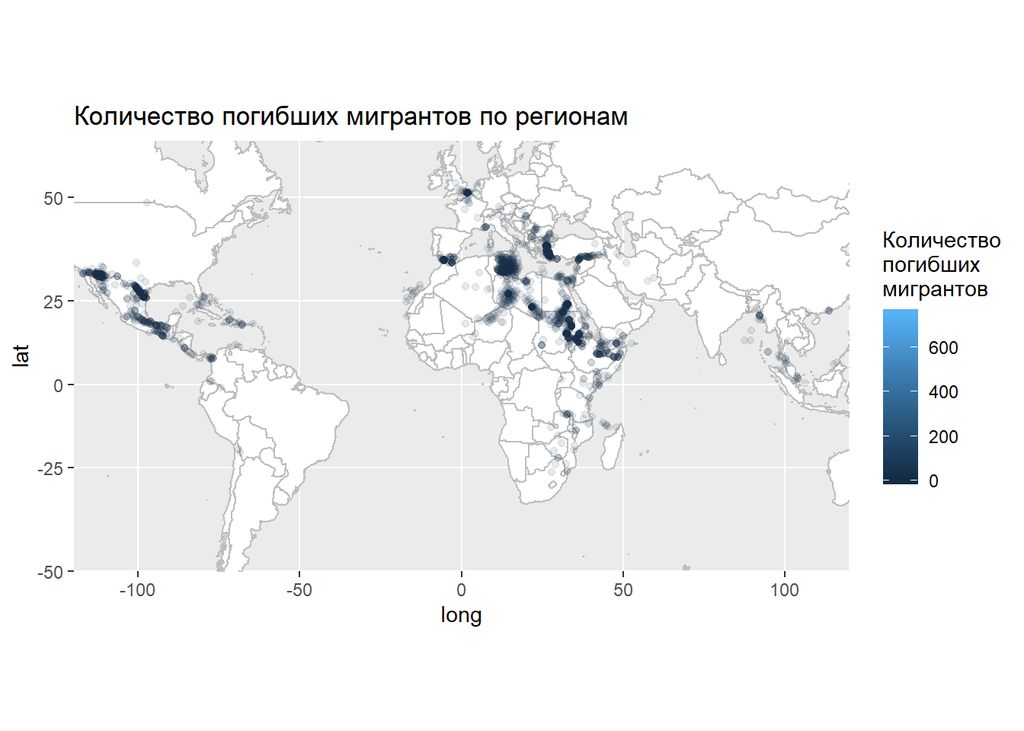

```r
worldMap <- map_data("world")
ggplot(worldMap) +
  geom_polygon(aes(long, lat, group = group), fill="white", color="grey") +
  geom_point(data=mm, aes(lon, lat, color=dead), alpha=0.1) +
  coord_map(xlim=c(-120,120),ylim=c(-50,60))+
  labs(title="Количество погибших мигрантов по регионам", color="Количество\nпогибших\nмигрантов")
```

Интересный пример исследования данного набора данных можно найти [здесь](https://www.kaggle.com/jmataya/visualize-deadly-syrian-migrant-routes-to-europe).